# Getting started with `EpiAware`

This tutorial introduces the basic functionality of `EpiAware`. `EpiAware` is a package for making inferences on epidemiological case/determined infection data using a model-based approach.

In this tutorial we consider a time series of case data and make inference on the underlying unobserved infections that generated the case data along with the implied time-varying reproduction number.

## Overview

The models we consider are discrete-time $t = 1,\dots, T$ with a latent random process, $Z_t$ generating stochasticity in the number of new infections $I_t$ at each time step. Observations are treated as downstream random variables determined by the actual infections and a model of infection to observation delay.

#### Mathematical definition

Let the parameters of the model be $\theta = (\theta_Z, \theta_I, \theta_O)$, then the overall infection observation process is:

$$\begin{align} Z_\cdot &\sim \mathcal{P}(\mathbb{R}^T) | \theta_Z, \\ I_0 &\sim f_0(\theta_I), \\ I_t &\sim g_I(\{I_s, Z_s\}_{s < t}, \theta_{I}), \\ y_t &\sim f_O(\{I_s\}_{s \leq t}, \theta_{O}). \end{align}$$

Where $\mathcal{P}(\mathbb{R}^T) | \theta_Z$ is a parametric process on $\mathbb{R}^T$. $f_0$ and $f_O$ are parametric distributions on, respectively, the initial number of infections and the observed case data conditional on underlying infections. $g_I$ is distribution of new infections conditional on infections and latent process in the past. Note that we assume that new infections are conditional on the strict past, whereas new observations can depend on infections on the same time step.

#### Code structure outline

An `EpiAware` model in code is created from three modular components:

- A `LatentModel`: This defines the model for $Z_\cdot$. This chooses $\mathcal{P}(\mathbb{R}^T) | \theta_Z$.
- An `EpiModel`: This defines a generative process for infections conditional on the latent process. This chooses $f_0(\theta_I)$, and $g_I(\{I_s, Z_s\}_{s < t}, \theta_{I})$.
- An `ObservationModel`: This defines the observation model. This chooses $f_O({I_s}_{s \leq t}, \theta_{O})$

We can bundle these three modular components into an `EpiProblem` struct along with a `tspan` field that defines how long the process last for. In this case,

```julia
tspan = (1, T)
```

## Model definition

```julia
begin
    using EpiAware
    using Turing
    using Distributions
    using StatsPlots
    using Random
    using DynamicPPL
    using Statistics
    using DataFramesMeta
    using LinearAlgebra
    using Transducers
    using ReverseDiff
    Random.seed!(1)
end
```

```
TaskLocalRNG()
```

## Direct infection `EpiModel`

This is a simple model where the unobserved log-infections are directly generated by the latent process $Z$.

$$\log I_t = \log I_0 + Z_t.$$

The `EpiData` constructor performs double interval censoring to convert our *continuous* estimate of the generation interval into a discretized version. We also implement right truncation using the keyword `D_gen`.

```julia
truth_GI = Gamma(2, 5)
```

```
Distributions.Gamma{Float64}(α=2.0, θ=5.0)
```

```julia
model_data = EpiData(gen_distribution = truth_GI,
    D_gen = 10.0)
```

```
EpiData{Float64, typeof(exp)}([0.056722565637507084, 0.0944813112842689, 0.11668723746973605, 0.12773814268679387, 0.130948497124998, 0.1287976856448402, 0.12312384970427602, 0.11527489380975135, 0.10622581663782862], 9, exp)
```

```julia
log_I0_prior = Normal(log(100.0), 1.0)
```

```
Distributions.Normal{Float64}(μ=4.605170185988092, σ=1.0)
```

```julia
epi_model = DirectInfections(model_data, log_I0_prior)
```

```
DirectInfections{Normal{Float64}}(EpiData{Float64, typeof(exp)}([0.056722565637507084, 0.0944813112842689, 0.11668723746973605, 0.12773814268679387, 0.130948497124998, 0.1287976856448402, 0.12312384970427602, 0.11527489380975135, 0.10622581663782862], 9, exp), Distributions.Normal{Float64}(μ=4.605170185988092, σ=1.0))
```

## Random walk `LatentModel`

As an example, we choose the latent process as a random walk with parameters $\theta_Z$:

- $Z_0$: Initial position.
- $\sigma^2_{Z}$: The step-size variance.

Conditional on the parameters the random walk is then generated by white noise:

$$\begin{align} Z_t &= Z_0 + \sigma_{RW} \sum_{t= 1}^T \epsilon_t, \\ \epsilon_t &\sim \mathcal{N}(0,1). \end{align}$$

In `EpiAware` we provide a constructor for random walk latent models with priors for $\theta_Z$. We choose priors,

$$\begin{align} Z_0 &\sim \mathcal{N}(0,1),\\ \sigma_{RW} &\sim \text{HalfNormal}(0.1 * \sqrt{\pi / 2})). \end{align}$$

```julia
rwp = EpiAware.RandomWalk(
    init_prior = Normal(),
    std_prior = EpiAware.EpiLatentModels.HalfNormal(0.1))
```

```
RandomWalk{Normal{Float64}, HalfNormal{Float64}}(Distributions.Normal{Float64}(μ=0.0, σ=1.0), HalfNormal{Float64}(μ=0.1))
```

We can supply a prior for the initial log_infections.

And construct the `EpiModel`.

```julia
latent = generate_latent_infs(epi_model, 20)
```

```
Model{typeof(generate_latent_infs), (:epi_model, :Z_t), (), (), Tuple{DirectInfections{Normal{Float64}}, Int64}, Tuple{}, DefaultContext}(EpiAware.EpiAwareBase.generate_latent_infs, (epi_model = DirectInfections{Normal{Float64}}(EpiData{Float64, typeof(exp)}([0.056722565637507084, 0.0944813112842689, 0.11668723746973605, 0.12773814268679387, 0.130948497124998, 0.1287976856448402, 0.12312384970427602, 0.11527489380975135, 0.10622581663782862], 9, exp), Distributions.Normal{Float64}(μ=4.605170185988092, σ=1.0)), Z_t = 20), NamedTuple(), DefaultContext())
```

```julia
rand(latent)
```

```
(init_incidence = 4.534587047034194,)
```

### Delayed Observations `ObservationModel`

The observation model is a negative binomial distribution parameterised with mean $\mu$ and 'successes' parameter $r$. The standard deviation *relative* to the mean $\sigma_{\text{rel}} = \sigma / \mu$ for negative binomial observations is,

$$\sigma_{\text{rel}} =(1/\sqrt{\mu}) + (1 / \sqrt{r}).$$

It is standard to use a half-t distribution for standard deviation priors (e.g. as argued in this [paper](http://www.stat.columbia.edu/~gelman/research/published/taumain.pdf)); we specialise this to a Half-Normal prior and use an *a priori* assumption that a typical observation fluctuation around the mean (when the mean is $\sim\mathcal{O}(10^2)$) would be 1%, which is close to Poisson noise.

This implies a standard deviation prior,

$$1 / \sqrt{r} \sim \text{HalfNormal}\Big(0.01 ~\sqrt{{\pi \over 2}}\Big).$$

The $\sqrt{{\pi \over 2}}$ factor ensures the correct prior mean (see [here](https://en.wikipedia.org/wiki/Half-normal_distribution)).

The expected observed cases are delayed infections. Delays are implemented as the action of a sparse kernel on the infections $I(t)$.

$$y_t \sim \text{NegBinomial}\Big(\mu = \sum_{s\geq 0} K[t, t-s] I(s), r\Big). \\$$

```julia
obs_model = LatentDelay(
    NegativeBinomialError(cluster_factor_prior = HalfNormal(0.01)),
    fill(0.25, 4)
)
```

```
LatentDelay{NegativeBinomialError{HalfNormal{Float64}, Float64}, Vector{Float64}}(NegativeBinomialError{HalfNormal{Float64}, Float64}(HalfNormal{Float64}(μ=0.01), 1.0e-6), [0.25, 0.25, 0.25, 0.25])
```

## `EpiProblem`

```julia
epi_prob = EpiProblem(epi_model = epi_model,
    latent_model = rwp,
    observation_model = obs_model,
    tspan = (1, 100))
```

```
EpiProblem{DirectInfections{Normal{Float64}}, RandomWalk{Normal{Float64}, HalfNormal{Float64}}, LatentDelay{NegativeBinomialError{HalfNormal{Float64}, Float64}, Vector{Float64}}}(DirectInfections{Normal{Float64}}(EpiData{Float64, typeof(exp)}([0.056722565637507084, 0.0944813112842689, 0.11668723746973605, 0.12773814268679387, 0.130948497124998, 0.1287976856448402, 0.12312384970427602, 0.11527489380975135, 0.10622581663782862], 9, exp), Distributions.Normal{Float64}(μ=4.605170185988092, σ=1.0)), RandomWalk{Normal{Float64}, HalfNormal{Float64}}(Distributions.Normal{Float64}(μ=0.0, σ=1.0), HalfNormal{Float64}(μ=0.1)), LatentDelay{NegativeBinomialError{HalfNormal{Float64}, Float64}, Vector{Float64}}(NegativeBinomialError{HalfNormal{Float64}, Float64}(HalfNormal{Float64}(μ=0.01), 1.0e-6), [0.25, 0.25, 0.25, 0.25]), (1, 100))
```

We also set up the inference to occur over 100 days.

```julia
time_horizon = 100
```

```
100
```

We choose a simple observation model where infections are observed 0, 1, 2, 3 days later with equal probability.

## Generate cases from the `EpiAware` model

Having chosen an `EpiModel`, `LatentModel` and `ObservationModel`, we can implement the model as a [`Turing`](https://turinglang.org/dev/) model using `generate_epiaware`.

By giving `missing` to the first argument, we indicate that case data will be *generated* from the model rather than treated as fixed.

### Using `apply_method`

```julia
nodata = (y_t = missing,)
```

```
(y_t = missing,)
```

```julia
fixed_parameters = (rw_init = 0.0, init_incidence = log(100.0))
```

```
(rw_init = 0.0, init_incidence = 4.605170185988092)
```

```julia
sampled_epidemic = apply_method(epi_prob, DirectSample(), nodata;
    fix_parameters = fixed_parameters
)
```

```
EpiAwareObservables(Model{typeof(generate_epiaware), (:y_t, :time_steps, :epi_model), (:latent_model, :observation_model), (:y_t,), Tuple{Missing, Int64, DirectInfections{Normal{Float64}}}, Tuple{RandomWalk{Normal{Float64}, HalfNormal{Float64}}, LatentDelay{NegativeBinomialError{HalfNormal{Float64}, Float64}, Vector{Float64}}}, DynamicPPL.FixedContext{@NamedTuple{rw_init::Float64, init_incidence::Float64}, DefaultContext}}(EpiAware.EpiAwareBase.generate_epiaware, (y_t = missing, time_steps = 100, epi_model = DirectInfections{Normal{Float64}}(EpiData{Float64, typeof(exp)}([0.056722565637507084, 0.0944813112842689, 0.11668723746973605, 0.12773814268679387, 0.130948497124998, 0.1287976856448402, 0.12312384970427602, 0.11527489380975135, 0.10622581663782862], 9, exp), Distributions.Normal{Float64}(μ=4.605170185988092, σ=1.0))), (latent_model = RandomWalk{Normal{Float64}, HalfNormal{Float64}}(Distributions.Normal{Float64}(μ=0.0, σ=1.0), HalfNormal{Float64}(μ=0.1)), observation_model = LatentDelay{NegativeBinomialError{HalfNormal{Float64}, Float64}, Vector{Float64}}(NegativeBinomialError{HalfNormal{Float64}, Float64}(HalfNormal{Float64}(μ=0.01), 1.0e-6), [0.25, 0.25, 0.25, 0.25])), FixedContext((rw_init = 0.0, init_incidence = 4.605170185988092), DynamicPPL.DefaultContext())), nothing, (ϵ_t = [0.2784058141640002, -0.5958244153640522, 0.04665938957338174, 1.0857940215432762, -1.5765649225859841, 0.1759399913010747, 0.8653808054093252, -1.1886800049871964, -1.8920155582259128, 0.21787878613277867  …  0.747446113596017, -0.5200214906974596, -0.25155469243873996, 1.219317449444866, 1.0026816589160366, -0.23882187003406924, 1.546409924955377, -0.5841980481085709, 0.46774878539798725, -0.3915200830436959], σ_RW = 0.2003414364598456, cluster_factor = 0.009599751054531477, var"y_t[1]" = 23, var"y_t[2]" = 53, var"y_t[3]" = 72, var"y_t[4]" = 87, var"y_t[5]" = 110, var"y_t[6]" = 90, var"y_t[7]" = 97, var"y_t[8]" = 96, var"y_t[9]" = 88, var"y_t[10]" = 92, var"y_t[11]" = 66, var"y_t[12]" = 46, var"y_t[13]" = 49, var"y_t[14]" = 70, var"y_t[15]" = 51, var"y_t[16]" = 51, var"y_t[17]" = 57, var"y_t[18]" = 32, var"y_t[19]" = 26, var"y_t[20]" = 30, var"y_t[21]" = 24, var"y_t[22]" = 17, var"y_t[23]" = 22, var"y_t[24]" = 16, var"y_t[25]" = 16, var"y_t[26]" = 9, var"y_t[27]" = 30, var"y_t[28]" = 25, var"y_t[29]" = 24, var"y_t[30]" = 29, var"y_t[31]" = 27, var"y_t[32]" = 21, var"y_t[33]" = 26, var"y_t[34]" = 16, var"y_t[35]" = 23, var"y_t[36]" = 11, var"y_t[37]" = 10, var"y_t[38]" = 13, var"y_t[39]" = 11, var"y_t[40]" = 12, var"y_t[41]" = 8, var"y_t[42]" = 10, var"y_t[43]" = 9, var"y_t[44]" = 4, var"y_t[45]" = 11, var"y_t[46]" = 7, var"y_t[47]" = 24, var"y_t[48]" = 7, var"y_t[49]" = 12, var"y_t[50]" = 6, var"y_t[51]" = 13, var"y_t[52]" = 10, var"y_t[53]" = 9, var"y_t[54]" = 9, var"y_t[55]" = 4, var"y_t[56]" = 10, var"y_t[57]" = 1, var"y_t[58]" = 7, var"y_t[59]" = 9, var"y_t[60]" = 7, var"y_t[61]" = 7, var"y_t[62]" = 6, var"y_t[63]" = 11, var"y_t[64]" = 9, var"y_t[65]" = 15, var"y_t[66]" = 12, var"y_t[67]" = 12, var"y_t[68]" = 12, var"y_t[69]" = 11, var"y_t[70]" = 4, var"y_t[71]" = 10, var"y_t[72]" = 6, var"y_t[73]" = 5, var"y_t[74]" = 15, var"y_t[75]" = 11, var"y_t[76]" = 16, var"y_t[77]" = 11, var"y_t[78]" = 18, var"y_t[79]" = 10, var"y_t[80]" = 25, var"y_t[81]" = 18, var"y_t[82]" = 22, var"y_t[83]" = 37, var"y_t[84]" = 27, var"y_t[85]" = 34, var"y_t[86]" = 47, var"y_t[87]" = 30, var"y_t[88]" = 27, var"y_t[89]" = 68, var"y_t[90]" = 43, var"y_t[91]" = 46, var"y_t[92]" = 43, var"y_t[93]" = 49, var"y_t[94]" = 41, var"y_t[95]" = 44, var"y_t[96]" = 61, var"y_t[97]" = 53, var"y_t[98]" = 72, var"y_t[99]" = 68, var"y_t[100]" = 74), (generated_y_t = [23, 53, 72, 87, 110, 90, 97, 96, 88, 92  …  46, 43, 49, 41, 44, 61, 53, 72, 68, 74], I_t = [105.73610417760572, 93.83876911999515, 94.72006871563157, 117.73724809177845, 85.85021994497663, 88.93023802012267, 105.76544439350556, 83.35278265701943, 57.05597931301785, 59.60163628229336  …  45.547621741118085, 41.0412048287163, 39.02411269958201, 49.822143746585205, 60.90639775257483, 58.0608910832364, 79.14663663180612, 70.40492483023166, 77.32154834239392, 71.48838460465423], Z_t = [0.05577622072838862, -0.06359209852349329, -0.05424428939202245, 0.16328524458347005, -0.15256603667961127, -0.11731796609162123, 0.0560536675488611, -0.18208819214137026, -0.5611373068807263, -0.5174871578927579  …  -0.786411775695318, -0.8905936281316372, -0.940990456563029, -0.6967106472406894, -0.4958319633815097, -0.5436778798821617, -0.23386789416083936, -0.3509069702959484, -0.2571975067269676, -0.33563520256681967], process_aux = (σ_RW = 0.2003414364598456, rw_init = 0.0, cluster_factor = 0.009599751054531477)))
```

```julia
let
    plot(sampled_epidemic.generated.I_t,
        label = "I_t",
        xlabel = "Time",
        ylabel = "Infections",
        title = "Generated Infections")
    scatter!(sampled_epidemic.generated.generated_y_t, lab = "Cases")
end
```

[figure not shown]

### Direct interaction with `Turing` model

```julia
full_model = generate_epiaware(missing, time_horizon,
    epi_model;
    latent_model = rwp,
    observation_model = obs_model)
```

```
Model{typeof(generate_epiaware), (:y_t, :time_steps, :epi_model), (:latent_model, :observation_model), (:y_t,), Tuple{Missing, Int64, DirectInfections{Normal{Float64}}}, Tuple{RandomWalk{Normal{Float64}, HalfNormal{Float64}}, LatentDelay{NegativeBinomialError{HalfNormal{Float64}, Float64}, Vector{Float64}}}, DefaultContext}(EpiAware.EpiAwareBase.generate_epiaware, (y_t = missing, time_steps = 100, epi_model = DirectInfections{Normal{Float64}}(EpiData{Float64, typeof(exp)}([0.056722565637507084, 0.0944813112842689, 0.11668723746973605, 0.12773814268679387, 0.130948497124998, 0.1287976856448402, 0.12312384970427602, 0.11527489380975135, 0.10622581663782862], 9, exp), Distributions.Normal{Float64}(μ=4.605170185988092, σ=1.0))), (latent_model = RandomWalk{Normal{Float64}, HalfNormal{Float64}}(Distributions.Normal{Float64}(μ=0.0, σ=1.0), HalfNormal{Float64}(μ=0.1)), observation_model = LatentDelay{NegativeBinomialError{HalfNormal{Float64}, Float64}, Vector{Float64}}(NegativeBinomialError{HalfNormal{Float64}, Float64}(HalfNormal{Float64}(μ=0.01), 1.0e-6), [0.25, 0.25, 0.25, 0.25])), DefaultContext())
```

We choose some fixed parameters:

- Initial incidence is 100.
- In the direct infection model, the initial incidence and in the initial value of the random walk form a non-identifiable pair. Therefore, we fix $Z_0 = 0$.

We fix these parameters using `fix`, and generate a random epidemic.

```julia
cond_generative_model = fix(full_model, fixed_parameters)
```

```
Model{typeof(generate_epiaware), (:y_t, :time_steps, :epi_model), (:latent_model, :observation_model), (:y_t,), Tuple{Missing, Int64, DirectInfections{Normal{Float64}}}, Tuple{RandomWalk{Normal{Float64}, HalfNormal{Float64}}, LatentDelay{NegativeBinomialError{HalfNormal{Float64}, Float64}, Vector{Float64}}}, DynamicPPL.FixedContext{@NamedTuple{rw_init::Float64, init_incidence::Float64}, DefaultContext}}(EpiAware.EpiAwareBase.generate_epiaware, (y_t = missing, time_steps = 100, epi_model = DirectInfections{Normal{Float64}}(EpiData{Float64, typeof(exp)}([0.056722565637507084, 0.0944813112842689, 0.11668723746973605, 0.12773814268679387, 0.130948497124998, 0.1287976856448402, 0.12312384970427602, 0.11527489380975135, 0.10622581663782862], 9, exp), Distributions.Normal{Float64}(μ=4.605170185988092, σ=1.0))), (latent_model = RandomWalk{Normal{Float64}, HalfNormal{Float64}}(Distributions.Normal{Float64}(μ=0.0, σ=1.0), HalfNormal{Float64}(μ=0.1)), observation_model = LatentDelay{NegativeBinomialError{HalfNormal{Float64}, Float64}, Vector{Float64}}(NegativeBinomialError{HalfNormal{Float64}, Float64}(HalfNormal{Float64}(μ=0.01), 1.0e-6), [0.25, 0.25, 0.25, 0.25])), FixedContext((rw_init = 0.0, init_incidence = 4.605170185988092), DynamicPPL.DefaultContext()))
```

```julia
random_epidemic = rand(cond_generative_model)
```

```
(ϵ_t = [-0.22738837624979108, 0.4411947505368261, -0.7794253474517835, -1.2399601139568195, -0.23134988131907536, -0.6476427304207877, -1.5654035783240514, 1.9497301195114662, 0.8631316311773468, 0.43624889638621506  …  0.4890990870361649, -0.8235369111407668, -0.5977732492782347, 0.9654914030100759, 0.4224487655965624, 0.46577370299205073, -0.6945136303794232, -1.6821602588733027, 0.10741678272117461, 0.8777006710452712], σ_RW = 0.033870260343540994, cluster_factor = 0.008068549498290235, var"y_t[1]" = 19, var"y_t[2]" = 51, var"y_t[3]" = 80, var"y_t[4]" = 92, var"y_t[5]" = 111, var"y_t[6]" = 99, var"y_t[7]" = 88, var"y_t[8]" = 91, var"y_t[9]" = 106, var"y_t[10]" = 95, var"y_t[11]" = 110, var"y_t[12]" = 101, var"y_t[13]" = 81, var"y_t[14]" = 85, var"y_t[15]" = 84, var"y_t[16]" = 77, var"y_t[17]" = 98, var"y_t[18]" = 66, var"y_t[19]" = 73, var"y_t[20]" = 90, var"y_t[21]" = 72, var"y_t[22]" = 71, var"y_t[23]" = 82, var"y_t[24]" = 102, var"y_t[25]" = 93, var"y_t[26]" = 85, var"y_t[27]" = 90, var"y_t[28]" = 98, var"y_t[29]" = 96, var"y_t[30]" = 84, var"y_t[31]" = 88, var"y_t[32]" = 105, var"y_t[33]" = 96, var"y_t[34]" = 81, var"y_t[35]" = 98, var"y_t[36]" = 101, var"y_t[37]" = 97, var"y_t[38]" = 87, var"y_t[39]" = 106, var"y_t[40]" = 102, var"y_t[41]" = 101, var"y_t[42]" = 79, var"y_t[43]" = 111, var"y_t[44]" = 91, var"y_t[45]" = 84, var"y_t[46]" = 102, var"y_t[47]" = 93, var"y_t[48]" = 85, var"y_t[49]" = 111, var"y_t[50]" = 96, var"y_t[51]" = 104, var"y_t[52]" = 100, var"y_t[53]" = 103, var"y_t[54]" = 83, var"y_t[55]" = 99, var"y_t[56]" = 126, var"y_t[57]" = 77, var"y_t[58]" = 73, var"y_t[59]" = 98, var"y_t[60]" = 75, var"y_t[61]" = 84, var"y_t[62]" = 97, var"y_t[63]" = 91, var"y_t[64]" = 98, var"y_t[65]" = 78, var"y_t[66]" = 93, var"y_t[67]" = 91, var"y_t[68]" = 88, var"y_t[69]" = 78, var"y_t[70]" = 84, var"y_t[71]" = 80, var"y_t[72]" = 81, var"y_t[73]" = 95, var"y_t[74]" = 86, var"y_t[75]" = 92, var"y_t[76]" = 60, var"y_t[77]" = 85, var"y_t[78]" = 90, var"y_t[79]" = 75, var"y_t[80]" = 89, var"y_t[81]" = 92, var"y_t[82]" = 96, var"y_t[83]" = 96, var"y_t[84]" = 113, var"y_t[85]" = 107, var"y_t[86]" = 87, var"y_t[87]" = 67, var"y_t[88]" = 106, var"y_t[89]" = 103, var"y_t[90]" = 89, var"y_t[91]" = 82, var"y_t[92]" = 100, var"y_t[93]" = 85, var"y_t[94]" = 90, var"y_t[95]" = 82, var"y_t[96]" = 78, var"y_t[97]" = 108, var"y_t[98]" = 71, var"y_t[99]" = 89, var"y_t[100]" = 73)
```

```julia
true_infections = generated_quantities(cond_generative_model, random_epidemic).I_t
```

```
100-element Vector{Float64}:
  99.23278786227766
 100.72679619164572
  98.10246798576104
  94.0677015454594
  93.33347865573941
  91.30842336461846
  86.59329753437329
   ⋮
  90.8297042388592
  92.2739848854322
  90.12872177129705
  85.13716693736791
  85.44748006014389
  88.02579258868938
```

```julia
generated_obs = generated_quantities(cond_generative_model, random_epidemic).generated_y_t
```

```
100-element Vector{Int64}:
  19
  51
  80
  92
 111
  99
  88
   ⋮
  82
  78
 108
  71
  89
  73
```

```julia
let
    plot(true_infections,
        label = "I_t",
        xlabel = "Time",
        ylabel = "Infections",
        title = "Generated Infections")
    scatter!(generated_obs, lab = "generated cases")
end
```

[figure not shown]

## Inference

Fixing $Z_0 = 0$ for the random walk was based on inference principles; in this model $Z_0$ and $\log I_0$ are non-identifiable.

However, we now treat the generated data as `truth_data` and make inference without fixing any other parameters.

We do the inference by MCMC/NUTS using the `Turing` NUTS sampler with default warm-up steps.

```julia
truth_data = generated_obs
```

```
100-element Vector{Int64}:
  19
  51
  80
  92
 111
  99
  88
   ⋮
  82
  78
 108
  71
  89
  73
```

We now make the model but fixing the initial condition of the random walk to be 0 and conditioning on the observed data.

```julia
inference_model = full_model |>
                  model -> fix(model, fixed_parameters) |>
                           model -> condition(model, (y_t = truth_data))
```

```
Model{typeof(generate_epiaware), (:y_t, :time_steps, :epi_model), (:latent_model, :observation_model), (:y_t,), Tuple{Missing, Int64, DirectInfections{Normal{Float64}}}, Tuple{RandomWalk{Normal{Float64}, HalfNormal{Float64}}, LatentDelay{NegativeBinomialError{HalfNormal{Float64}, Float64}, Vector{Float64}}}, ConditionContext{@NamedTuple{y_t::Vector{Int64}}, DynamicPPL.FixedContext{@NamedTuple{rw_init::Float64, init_incidence::Float64}, DefaultContext}}}(EpiAware.EpiAwareBase.generate_epiaware, (y_t = missing, time_steps = 100, epi_model = DirectInfections{Normal{Float64}}(EpiData{Float64, typeof(exp)}([0.056722565637507084, 0.0944813112842689, 0.11668723746973605, 0.12773814268679387, 0.130948497124998, 0.1287976856448402, 0.12312384970427602, 0.11527489380975135, 0.10622581663782862], 9, exp), Distributions.Normal{Float64}(μ=4.605170185988092, σ=1.0))), (latent_model = RandomWalk{Normal{Float64}, HalfNormal{Float64}}(Distributions.Normal{Float64}(μ=0.0, σ=1.0), HalfNormal{Float64}(μ=0.1)), observation_model = LatentDelay{NegativeBinomialError{HalfNormal{Float64}, Float64}, Vector{Float64}}(NegativeBinomialError{HalfNormal{Float64}, Float64}(HalfNormal{Float64}(μ=0.01), 1.0e-6), [0.25, 0.25, 0.25, 0.25])), ConditionContext((y_t = [19, 51, 80, 92, 111, 99, 88, 91, 106, 95, 110, 101, 81, 85, 84, 77, 98, 66, 73, 90, 72, 71, 82, 102, 93, 85, 90, 98, 96, 84, 88, 105, 96, 81, 98, 101, 97, 87, 106, 102, 101, 79, 111, 91, 84, 102, 93, 85, 111, 96, 104, 100, 103, 83, 99, 126, 77, 73, 98, 75, 84, 97, 91, 98, 78, 93, 91, 88, 78, 84, 80, 81, 95, 86, 92, 60, 85, 90, 75, 89, 92, 96, 96, 113, 107, 87, 67, 106, 103, 89, 82, 100, 85, 90, 82, 78, 108, 71, 89, 73],), FixedContext((rw_init = 0.0, init_incidence = 4.605170185988092), DynamicPPL.DefaultContext())))
```

```julia
num_threads = min(10, Threads.nthreads())
```

```
1
```

```julia
sampling_method = EpiMethod(
    pre_sampler_steps = [ManyPathfinder(nruns = 100, maxiters = 100)],
    sampler = NUTSampler(adtype = AutoReverseDiff(true),
        ndraws = 1000,
        nchains = num_threads,
        mcmc_parallel = MCMCThreads())
)
```

[output not shown]

```julia
sol = apply_method(inference_model, sampling_method)
```

[output not shown]

```julia
sol.samples
```

|  | iteration | chain | ϵ_t[1] | ϵ_t[2] | ϵ_t[3] | ϵ_t[4] | ϵ_t[5] | ϵ_t[6] | ... |
| --- | --- | --- | --- | --- | --- | --- | --- | --- | --- |
| 1 | 501 | 1 | 6.33709 | 8.33504 | 0.266433 | -2.07837 | 0.886043 | -0.698668 |  |
| 2 | 502 | 1 | 5.50138 | 9.78071 | 0.178576 | -1.62414 | 0.346592 | 0.0507119 |  |
| 3 | 503 | 1 | 5.28306 | 10.1029 | 0.282616 | -2.97006 | 1.22639 | -0.28545 |  |
| 4 | 504 | 1 | 7.26468 | 8.9686 | -0.000623351 | -0.280676 | -2.01958 | 1.17044 |  |
| 5 | 505 | 1 | 5.0565 | 10.2875 | 0.474562 | -1.47014 | 0.496824 | 0.0254037 |  |
| 6 | 506 | 1 | 7.28205 | 8.05109 | -0.497115 | -0.148262 | 0.0850492 | 0.535601 |  |
| 7 | 507 | 1 | 6.92199 | 9.01971 | 0.504812 | -0.121329 | -1.70896 | 1.41487 |  |
| 8 | 508 | 1 | 5.81169 | 9.08153 | -0.793938 | -0.430074 | 0.275331 | -0.0318275 |  |
| 9 | 509 | 1 | 5.78784 | 10.9669 | 0.551944 | -1.25352 | -0.19023 | 0.922711 |  |
| 10 | 510 | 1 | 5.52343 | 9.81062 | -0.742554 | 0.56017 | -0.38374 | -0.196471 |  |
| ... |  |  |  |  |  |  |  |  |  |

Alternatively, we could dispatch on a `EpiProblem` and optionally pass data, fixed parameters, and conditioned parameters.

### Initialising inference

It is possible for the default warm-up process for NUTS to get stuck in low probability or otherwise degenerate regions of parameter space.

To make NUTS more robust we provide `manypathfinder`, which is built on pathfinder variational inference from [Pathfinder.jl](https://mlcolab.github.io/Pathfinder.jl/stable/). `manypathfinder` runs `nruns` pathfinder processes on the inference problem and returns the pathfinder run with maximum estimated ELBO.

`manypathfinder` differs from `Pathfinder.multipathfinder`; `multipathfinder` is aimed at sampling from a potentially non-Gaussian target distribution which is first approximated as a uniformly weighted collection of normal approximations from pathfinder runs. `manypathfinder` is aimed at moving rapidly to a 'good' part of parameter space, and is robust to runs that fail.

We can use draws from the best pathfinder run to initialise NUTS.

### Predictive plotting

We can spaghetti plot generated case data from the version of the model *which hasn't conditioned on case data* using posterior parameters inferred from the version conditioned on observed data. This is known as *posterior predictive checking*, and is a useful diagnostic tool for Bayesian inference (see [here](http://www.stat.columbia.edu/~gelman/book/BDA3.pdf)).

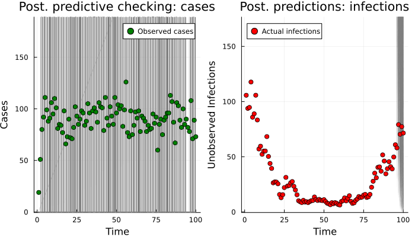

```julia
let
    post_check_y_t = mapreduce(
        hcat, generated_quantities(inference_model, sol.samples)) do gen
        gen.generated_y_t
    end

    predicted_I_t = mapreduce(
        hcat, generated_quantities(inference_model, sol.samples)) do gen
        gen.I_t
    end

    p1 = plot(post_check_y_t, c = :grey, alpha = 0.05, lab = "")
    scatter!(p1, truth_data,
        lab = "Observed cases",
        xlabel = "Time",
        ylabel = "Cases",
        title = "Post. predictive checking: cases",
        ylims = (-0.5, maximum(truth_data) * 1.5),
        c = :green)

    p2 = plot(predicted_I_t, c = :grey, alpha = 0.05, lab = "")
    scatter!(p2, sampled_epidemic.generated.I_t,
        lab = "Actual infections",
        xlabel = "Time",
        ylabel = "Unobserved Infections",
        title = "Post. predictions: infections",
        ylims = (-0.5, maximum(sampled_epidemic.generated.I_t) * 1.5),
        c = :red)

    plot(p1, p2,
        layout = (1, 2),
        size = (700, 400))
end
```

As well as checking the posterior predictions for latent infections, we can also check how well inference recovered unknown parameters, such as the random walk variance or the cluster factor of the negative binomial observations.

```julia
let
    parameters_to_plot = (:σ_RW, :cluster_factor)

    plts = map(parameters_to_plot) do name
        var_samples = sol.samples[name] |> vec
        histogram(var_samples,
            bins = 50,
            norm = :pdf,
            lw = 0,
            fillalpha = 0.5,
            lab = "MCMC")
        vline!([getfield(sampled_epidemic.samples, name)], lab = "True value")
        title!(string(name))
    end
    plot(plts..., layout = (2, 1))
end
```

[figure not shown]

## Reproductive number back-calculation

`EpiAware` models do not need to specify a time-varying reproductive number $\mathcal{R}_t$ to generate $I_\cdot$, however, this is often a quantity of interest. When not directly used we will typically back-calculate $\mathcal{R}_t$ from the generated infections:

$$\mathcal{R}_t = {I_t \over \sum_{s \geq 1} g_s I_{t-s} }.$$

Where $g_s$ is a discrete generation interval. For this reason, even when not using a reproductive number approach directly, we ask for a generation interval.

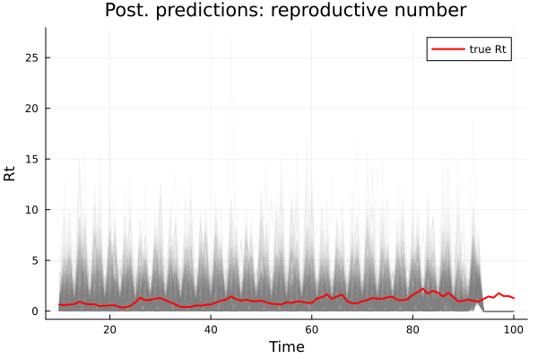

```julia
let
    n = epi_model.data.len_gen_int
    true_infections = sampled_epidemic.generated.I_t

    Rt_denom = [dot(reverse(epi_model.data.gen_int), true_infections[(t - n):(t - 1)])
                for t in (n + 1):length(true_infections)]
    true_Rt = true_infections[(n + 1):end] ./ Rt_denom

    predicted_Rt = mapreduce(
        hcat, generated_quantities(inference_model, sol.samples)) do gen
        _It = gen.I_t
        _Rt_denom = [dot(reverse(epi_model.data.gen_int), _It[(t - n):(t - 1)])
                     for t in (n + 1):length(_It)]
        Rt = _It[(n + 1):end] ./ _Rt_denom
    end

    plt = plot((n + 1):epi_prob.tspan[2], predicted_Rt, c = :grey, alpha = 0.05, lab = "")
    plot!(plt, (n + 1):epi_prob.tspan[2], true_Rt,
        lab = "true Rt",
        xlabel = "Time",
        ylabel = "Rt",
        title = "Post. predictions: reproductive number",
        c = :red,
        lw = 2)
end
```